# Elder Research Project

Thomas Wileman

March 20, 2019

[github repository](https://github.com/tmwileman/ASD-Predictor)

**Findings:** The data included a field called App_result. Whenever this result was greater than or equal to seven the ASD_YES feature equaled 1. This flaw in the data meant that all the questionaire data could be used to determine whether or not the user indicated they were on the autism spectrum.

Analysis

Set directory, load dataset, and install most of the packages needed for the data.

```r
setwd("~/TRENDI/Elder Interview")

data <- read.csv("Autism-Adult-Data (2).csv", header = T, stringsAsFactors = F)

library(stats)
#install.packages("dplyr")
library("dplyr", lib.loc="~/R/win-library/3.5")
#install.packages("DataExplorer")
library(DataExplorer)
#install.packages("ggplot2")
library(ggplot2)
#install.packages("ggthemes")
library(ggthemes)
#install.packages("stringr")
library(stringr)
#install.packages("MASS")
#library(caret)
#install.packages("tree")
library(tree)
#install.packages("partykit")
library(partykit)
```

```
##   rows columns discrete_columns continuous_columns all_missing_columns
## 1  704      21               10                 11                   0
##   total_missing_values complete_rows total_observations memory_usage
## 1                    0           704              14784       100752
```

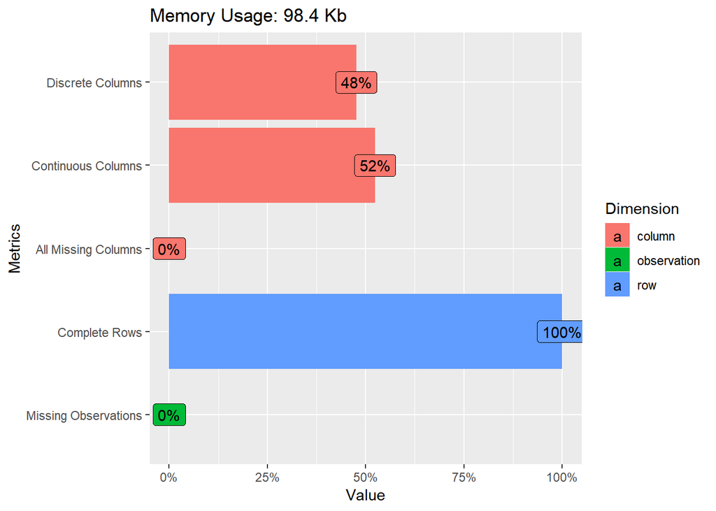

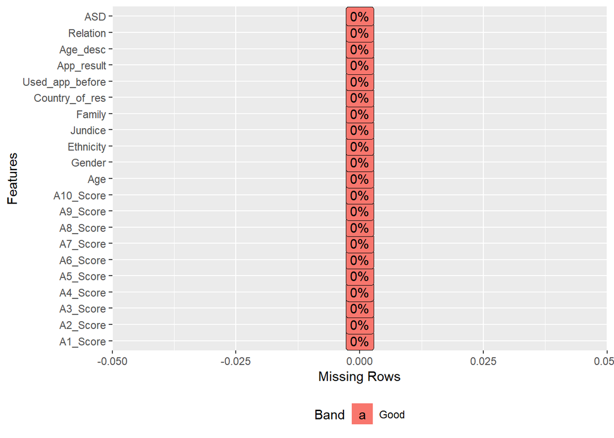

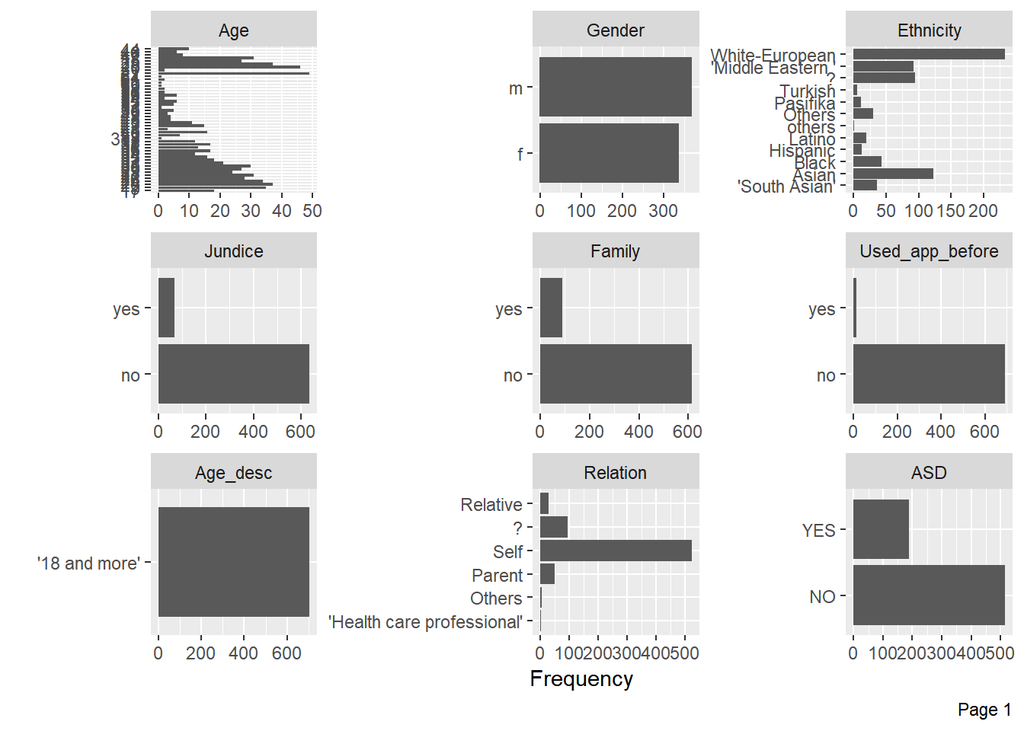

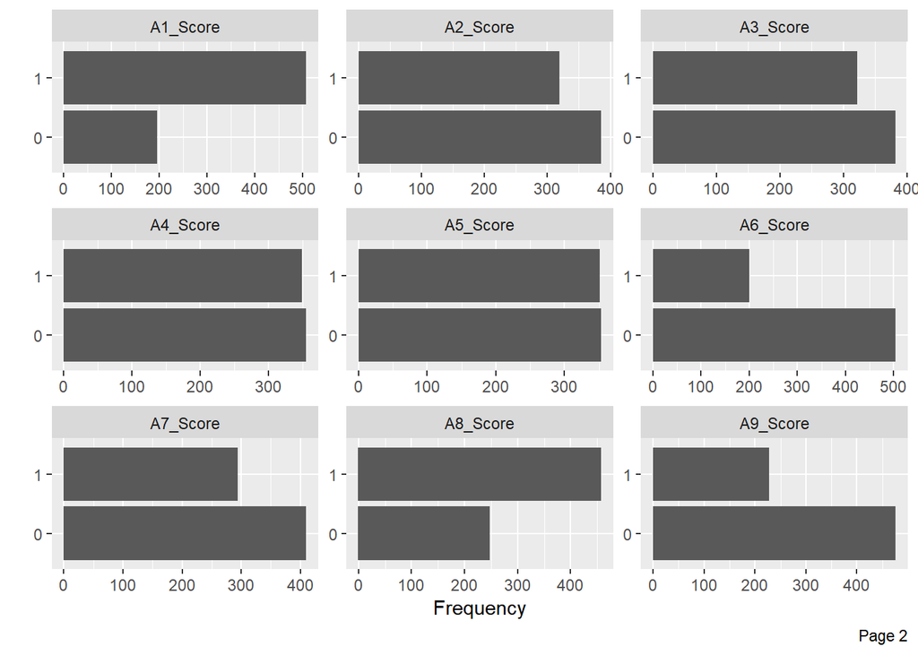

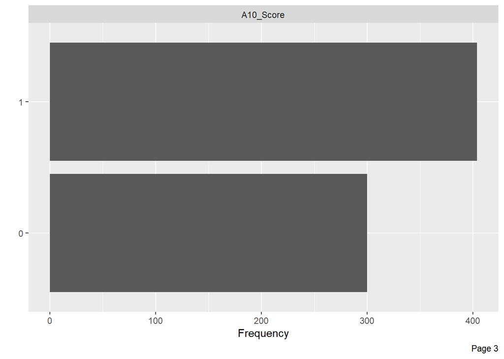

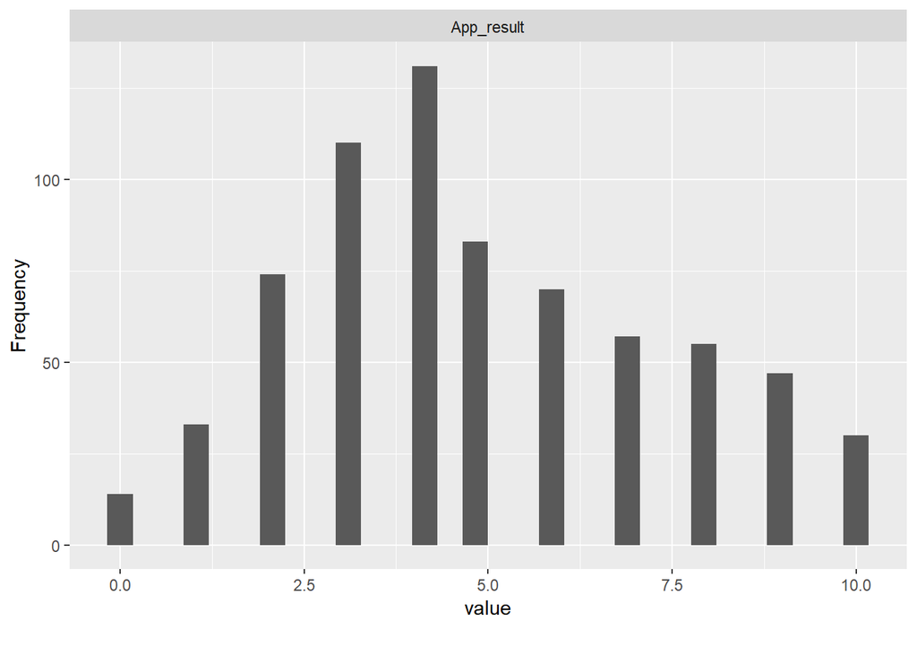

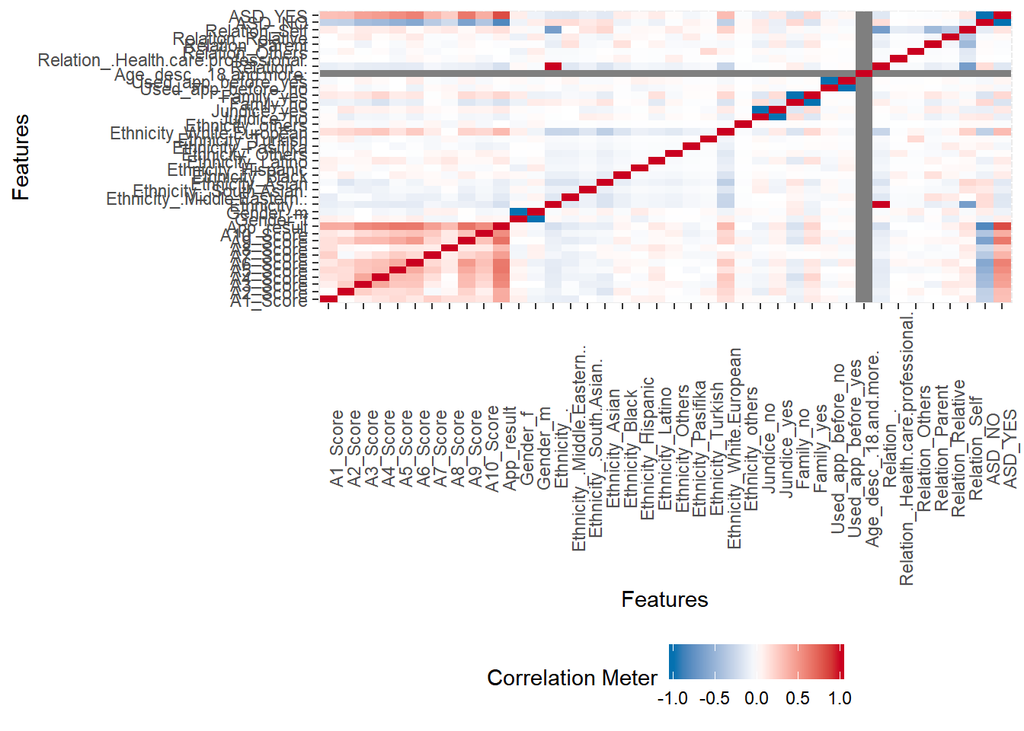

To clean data, first replace all question marks with NA.

```r
# Question marks in original data were used in place of NA
data[data == "?"] <- NA
```

Next, correct the identified outlier in the age column. ID the outlier using the IQR, replace it with the median.

```r
# Remove outlier age, replace it with the median then replace NA values with mean
x <- as.numeric(data$Age)
qnt <- quantile(x, probs=c(.25, .75), na.rm = T)
caps <- quantile(x, probs=c(.05, .95), na.rm = T)
H <- 1.5 * IQR(data$Age, na.rm = T)
x[x > (qnt[2] + H)] <- median(data$Age)
data$Age <- (x)
```

Then, replace missing ages with the mean age.

```r
#Impute the mean age
data$Age <- as.numeric(data$Age)
data$Age[is.na(data$Age)] = mean(data$Age, na.rm = TRUE)
```

```r
#Impute most frequent factor into relation
data$Relation[is.na(data$Relation)] <- "Self"
```

The next step is removing special characters and white space from character features.

```r
#Remove special characterers from country of residence, ethnicity, and relation
special.characters <- "a1~!@#$%^&*(){}_+:\"<>?,./;'[]-="
data$Country_of_res <- str_replace_all(data$Country_of_res, "[[:punct:]]", "")
data$Ethnicity <- str_replace_all(data$Ethnicity, "[[:punct:]]", "")
data$Relation <- str_replace_all(data$Relation, "[[:punct:]]", "")
data$Age_desc <- str_replace_all(data$Age_desc, "[[:punct:]]", "")
data$Country_of_res <- trimws(data$Country_of_res)
data$Ethnicity <- trimws(data$Ethnicity)
data$Relation <- trimws(data$Relation)
data$Age_desc <- trimws(data$Age_desc)
```

For ethnicity, replace missing values with the ethnicity most frequently reported in the corresponding country of residence. For the remaining missing values (10), replace with the most common observation, WhiteEuropean (35%). A better option would be to incorporate region and follow a similiar technique or impute from a distribution.

```r
# Impute unknown ethnicities with most frequent ethnicity from country of residence
data.region.ethnicity <- filter(data, !is.na(Ethnicity))
data.region.ethnicity <- subset(data.region.ethnicity, select = c("Ethnicity", "Country_of_res"))
max.table <- data.region.ethnicity %>%
  group_by(Country_of_res) %>%
  count(Ethnicity, Country_of_res) %>%
  filter(n == max(n))
data$Ethnicity[is.na(data$Ethnicity)] <- max.table$Ethnicity[match(data$Country_of_res, max.table$Country_of_res)][which(is.na(data$Ethnicity))]
data$Ethnicity[is.na(data$Ethnicity)] <- "WhiteEuropean"
```

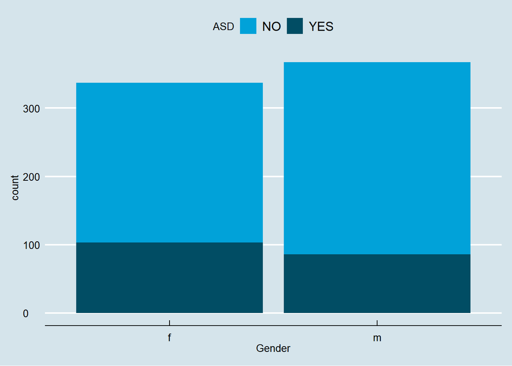

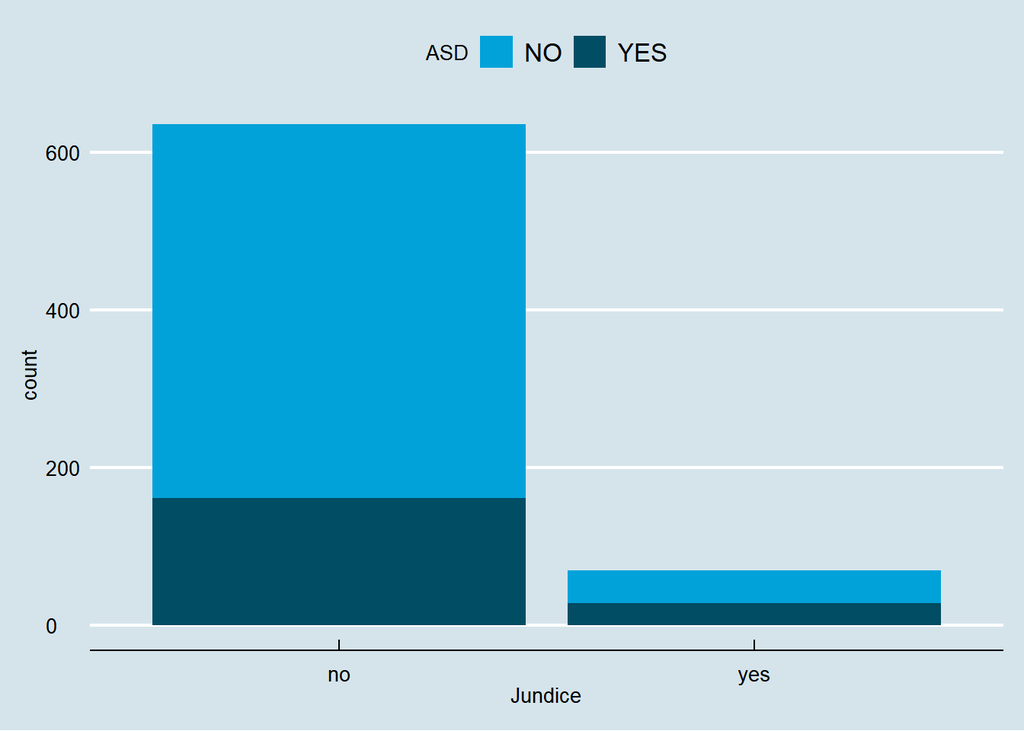

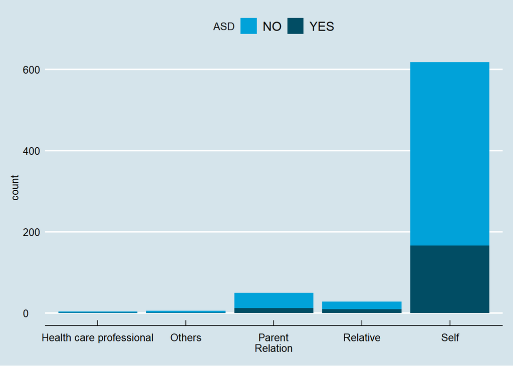

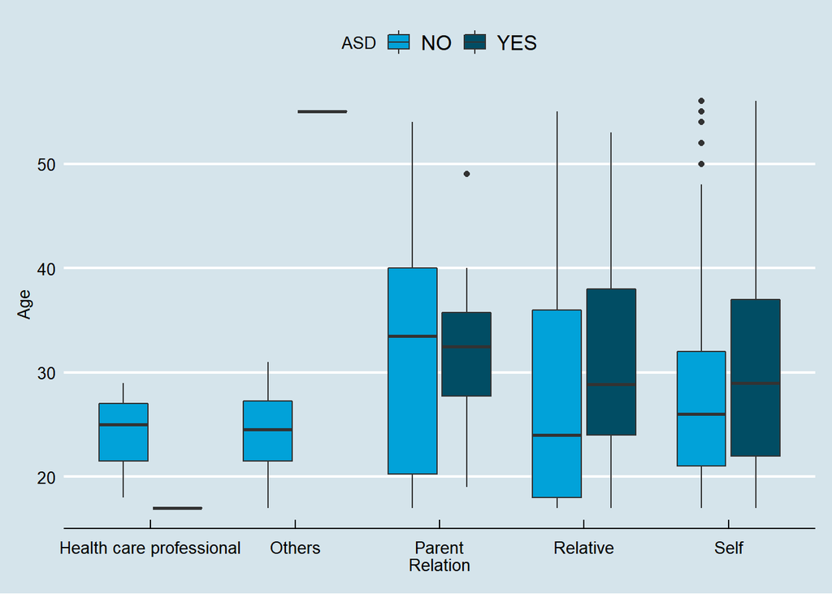

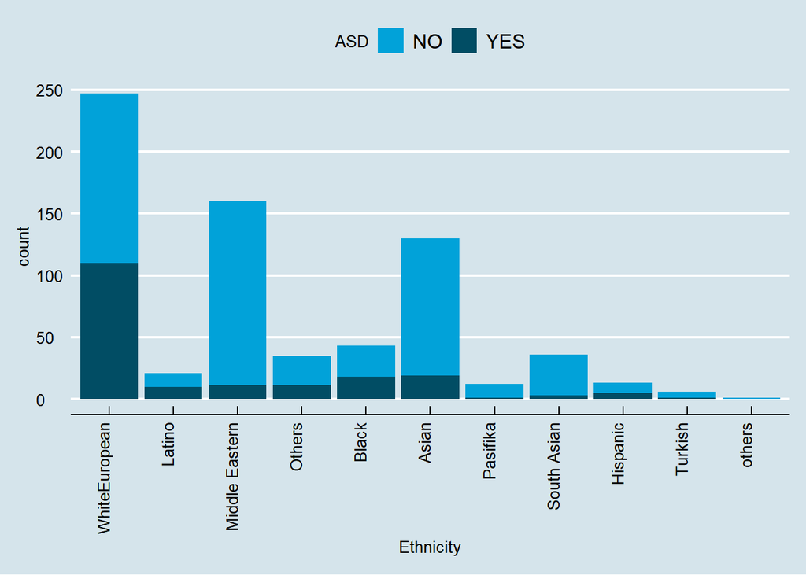

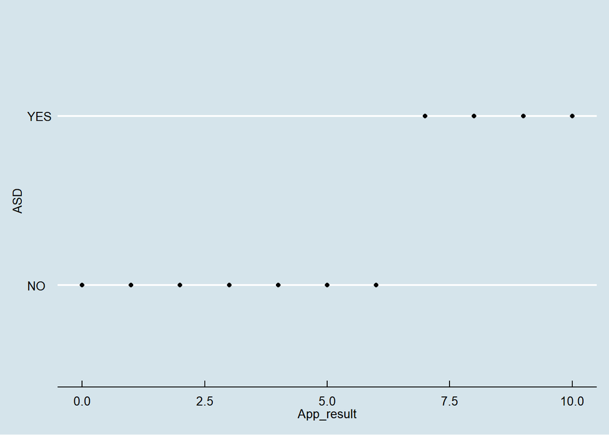

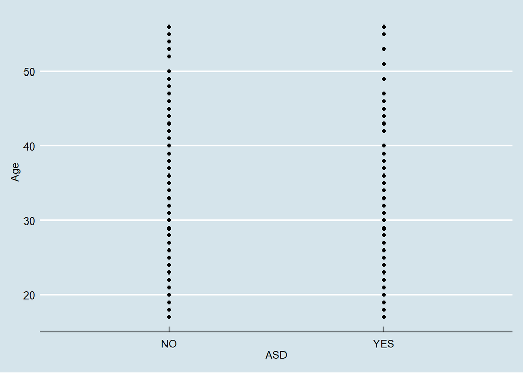

```r
data.clean <- data
data.clean <- drop_columns(data.clean, "Age_desc")
data.clean$Age <- as.integer(data.clean$Age)
data.clean$Gender <- ifelse(data.clean$Gender == "m", 0, 1)
data.clean$Ethnicity <- as.factor(data.clean$Ethnicity)
data.clean$Jundice <- ifelse(data.clean$Jundice == "yes", 1, 0)
data.clean$Family <- ifelse(data.clean$Family == "yes", 1, 0)
data.clean$Country_of_res <- as.factor(data.clean$Country_of_res)
data.clean$App_result <- as.integer(data.clean$App_result)
data.clean$ASD <- ifelse(data.clean$ASD == "YES", 1, 0)
```

Split data for training and testing.

```r
set.seed(100)
train <- sample(nrow(data.clean), 0.8*nrow(data.clean), replace = FALSE)
TrainSet <- data.clean[train,]
ValidSet <- data.clean[-train,]
```

Stepwise regression to identify important features. First regresses questionaire answers (including interactions) on ASD (target variable). It appears that a positive answer for each question is indicative of an ASD symptom. This is supported by the observation that any app_result >= 7 results in a positive ASD result.

```r
library(MASS)
data.answers <- drop_columns(data.clean, c("Ethnicity", "Country_of_res","Relation", "Age", "Gender", "Jundice", "Family", "Used_app_before", "App_result", "Age_desc"))
# Fit the model
answers.model <- glm(ASD ~ .^2, data = data.answers, family = binomial(link = logit),  control = list(maxit = 50)) %>%
  stepAIC(trace = FALSE, direction = c("forward"))
# Summarize the final selected model
summary(answers.model)
```

```
##
## Call:
## glm(formula = ASD ~ (A1_Score + A2_Score + A3_Score + A4_Score +
##     A5_Score + A6_Score + A7_Score + A8_Score + A9_Score + A10_Score)^2,
##     family = binomial(link = logit), data = data.answers, control = list(maxit = 50))
##
## Deviance Residuals:
##        Min          1Q      Median          3Q         Max
## -5.050e-06  -2.110e-08  -2.110e-08   2.110e-08   4.801e-06
##
## Coefficients:
##                      Estimate Std. Error z value Pr(>|z|)
## (Intercept)        -2.818e+01  2.137e+05       0        1
## A1_Score           -1.319e+01  7.286e+06       0        1
## A2_Score           -2.438e+00  1.458e+06       0        1
## A3_Score           -3.815e+01  3.613e+06       0        1
## A4_Score           -6.029e+01  1.938e+06       0        1
## A5_Score           -7.795e+01  4.081e+06       0        1
## A6_Score           -3.027e+01  3.155e+06       0        1
## A7_Score           -2.401e+01  2.127e+06       0        1
## A8_Score           -3.483e+01  2.111e+06       0        1
## A9_Score           -5.193e+01  2.093e+06       0        1
## A10_Score          -1.937e+01  2.004e+06       0        1
## A1_Score:A2_Score   3.379e+00  1.988e+06       0        1
## A1_Score:A3_Score   1.334e+01  9.652e+05       0        1
## A1_Score:A4_Score   8.595e+00  1.632e+06       0        1
## A1_Score:A5_Score   3.004e+01  1.108e+06       0        1
## A1_Score:A6_Score   2.577e+01  9.826e+05       0        1
## A1_Score:A7_Score   5.569e+00  3.736e+06       0        1
## A1_Score:A8_Score  -1.296e+01  3.341e+06       0        1
## A1_Score:A9_Score   2.729e+01  2.044e+06       0        1
## A1_Score:A10_Score  4.964e+00  1.851e+06       0        1
## A2_Score:A3_Score   1.166e+01  6.429e+05       0        1
## A2_Score:A4_Score   9.141e+00  6.476e+05       0        1
## A2_Score:A5_Score   1.850e+01  7.405e+05       0        1
## A2_Score:A6_Score   6.619e+00  6.285e+05       0        1
## A2_Score:A7_Score   7.374e+00  6.835e+05       0        1
## A2_Score:A8_Score   1.004e+01  7.303e+05       0        1
## A2_Score:A9_Score   1.259e+01  6.112e+05       0        1
## A2_Score:A10_Score  7.314e+00  6.659e+05       0        1
```

[output cut: 21 more lines]

```
## A6_Score:A10_Score  6.556e+00  8.737e+05       0        1
## A7_Score:A8_Score   1.425e+01  7.533e+05       0        1
## A7_Score:A9_Score   1.580e+01  6.556e+05       0        1
## A7_Score:A10_Score  1.436e+01  6.592e+05       0        1
## A8_Score:A9_Score   1.435e+01  7.515e+05       0        1
## A8_Score:A10_Score  1.049e+01  8.296e+05       0        1
## A9_Score:A10_Score  1.209e+01  6.383e+05       0        1
##
## (Dispersion parameter for binomial family taken to be 1)
##
##     Null deviance: 8.1907e+02  on 703  degrees of freedom
## Residual deviance: 5.2235e-10  on 648  degrees of freedom
## AIC: 112
##
## Number of Fisher Scoring iterations: 29
```

```r
data.demo <- drop_columns(data.clean, c("Age", "A1_Score", "A2_Score", "A3_Score", "A4_Score", "A5_Score", "A6_Score", "A7_Score", "A8_Score", "A9_Score", "A10_Score", "Used_app_before", "App_result", "Age_desc", "Relation", "Ethnicity", "Country_of_res"))
# Fit the model
demo.model <- glm(ASD ~ ., data = data.demo, family = binomial(link = logit),  control = list(maxit = 50))
# Summarize the final selected model
summary(demo.model)
```

```
##
## Call:
## glm(formula = ASD ~ ., family = binomial(link = logit), data = data.demo,
##     control = list(maxit = 50))
##
## Deviance Residuals:
##     Min       1Q   Median       3Q      Max
## -1.3648  -0.7740  -0.6763   1.2216   1.7819
##
## Coefficients:
##             Estimate Std. Error z value Pr(>|z|)
## (Intercept)  -1.3590     0.1324 -10.261  < 2e-16 ***
## Gender        0.3070     0.1743   1.761   0.0782 .
## Jundice       0.5339     0.2701   1.977   0.0481 *
## Family        0.9486     0.2348   4.040 5.34e-05 ***
## ---
## Signif. codes:  0 '***' 0.001 '**' 0.01 '*' 0.05 '.' 0.1 ' ' 1
##
## (Dispersion parameter for binomial family taken to be 1)
##
##     Null deviance: 819.07  on 703  degrees of freedom
## Residual deviance: 792.07  on 700  degrees of freedom
## AIC: 800.07
##
## Number of Fisher Scoring iterations: 4
```

Finally, classify via Random Forest.

```r
#install.packages("randomForest")
library(randomForest)
```

```r
data.Forest <- data
data.Forest$ASD <- as.factor(data.Forest$ASD)
data.Forest <- drop_columns(data.Forest, "Age_desc")
data.Forest$Age <- as.factor(data.Forest$Age)
data.Forest$Gender <- as.factor(data.Forest$Gender)
data.Forest$Ethnicity <- as.factor(data.Forest$Ethnicity)
data.Forest$Jundice <- as.factor(data.Forest$Jundice)
data.Forest$Family <- as.factor(data.Forest$Family)
data.Forest$Country_of_res <- as.factor(data.Forest$Country_of_res)
data.Forest$App_result <- as.factor(data.Forest$App_result)
data.Forest$Used_app_before <- as.factor(data.Forest$Used_app_before)
data.Forest$Relation <- as.factor(data.Forest$Relation)

train.forest <- sample(nrow(data.Forest), 0.8*nrow(data.Forest), replace = FALSE)
TrainSet.Forest <- data.Forest[train,]
ValidSet.Forest <- data.Forest[-train,]

data_list <- list(TrainSet.Forest)
plot_str(data_list)

forest.model <- randomForest(ASD ~ . - Country_of_res, data = TrainSet.Forest, importance = TRUE)
forest.model
```

```
##
## Call:
##  randomForest(formula = ASD ~ . - Country_of_res, data = TrainSet.Forest,      importance = TRUE)
##                Type of random forest: classification
##                      Number of trees: 500
## No. of variables tried at each split: 4
##
##         OOB estimate of  error rate: 0%
## Confusion matrix:
##      NO YES class.error
## NO  416   0           0
## YES   0 147           0
```

```r
# Predicting on train set
predTrain <- predict(forest.model, TrainSet.Forest, type = "class")
# Checking classification accuracy
predValid <- predict(forest.model, ValidSet.Forest, type = "class")
table(predTrain, TrainSet$ASD)
```

```
##
## predTrain   0   1
##       NO  416   0
##       YES   0 147
```

```r
table(predValid,ValidSet$ASD)
```

```
##
## predValid  0  1
##       NO  99  0
##       YES  0 42
```

```r
mean(predValid == ValidSet$ASD)
```

```
## [1] 0
```